# ITCM: Classification of Handwritten Digits

Introduction to Computational Mathematics/ Group 31/ Yan-Yu Chen(陳彥宇)/ Econ B05303134

## Problem Discription

The main goal of this project is to demonstrate how to recognize the images of handwritten digits with a concentration in $3$, $4$, and $5$ by matrix factorization, in particular, the singular value decomposition (SVD) method.

In this experiment, we divided the images from the MNIST database into two groups, the traing data and testing data. We then used SVD to built a classifier from the training data, and classifier evaluation by accuracy form testing data.

```python
import numpy as np
from numpy import linalg as LA
import matplotlib.pyplot as plt
import seaborn as sns
```

### MNIST Database ([Link)](http://yann.lecun.com/exdb/mnist/)

The images are collected from the famous MNIST (Modified National Institute of Standards and Technology) database. It is a database of handwritten digits that is commonly used for training various image processing systems. The data contains $60,000$ training images and $10,000$ testing images.Each image has been normalized to $28 \times 28$ pixels.

```python
mnist = np.load('mnist.npz')
x_train = mnist['x_train']
y_train = mnist['y_train']
x_train = x_train[y_train >= 3]
y_train = y_train[y_train >= 3]
x_train = x_train[y_train <= 5].reshape((14466,28,28))
y_train = y_train[y_train <= 5]

x_test = mnist['x_test']
y_test = mnist['y_test']
x_test = x_test[y_test >= 3]
y_test = y_test[y_test >= 3]
x_test = x_test[y_test <= 5].reshape((2884,28,28))
y_test = y_test[y_test <= 5]

print('x_train shape:', x_train.shape)
print('y_train shape:', y_train.shape)
print('x_test shape:', x_test.shape)
print('y_test shape:', y_test.shape)
x_train3 = x_train[y_train == 3]
x_train4 = x_train[y_train == 4]
x_train5 = x_train[y_train == 5]
```

```
x_train shape: (14466, 28, 28)
y_train shape: (14466,)
x_test shape: (2884, 28, 28)
y_test shape: (2884,)
```

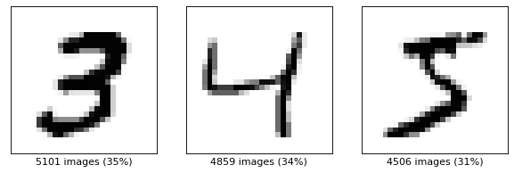

```python
x_train3 = x_train[y_train == 3]
x_train4 = x_train[y_train == 4]
x_train5 = x_train[y_train == 5]

fig = plt.figure(figsize=(9,6), dpi=80)
plt.subplot(1,3,1, xticks=[], yticks=[])
plt.imshow(x_train3[0], cmap='Greys')
plt.xlabel(str(x_train3.shape[0])+
           ' images ('+str(round(x_train3.shape[0]/x_train.shape[0]*100))+'%)')
plt.subplot(1,3,2, xticks=[], yticks=[])
plt.imshow(x_train4[0], cmap='Greys')
plt.xlabel(str(x_train4.shape[0])+
           ' images ('+str(round(x_train4.shape[0]/x_train.shape[0]*100))+'%)')
plt.subplot(1,3,3, xticks=[], yticks=[])
plt.imshow(x_train5[0], cmap='Greys')
plt.xlabel(str(x_train5.shape[0])+
           ' images ('+str(round(x_train5.shape[0]/x_train.shape[0]*100))+'%)')
plt.show()
```

### Sample Images from the Training Data

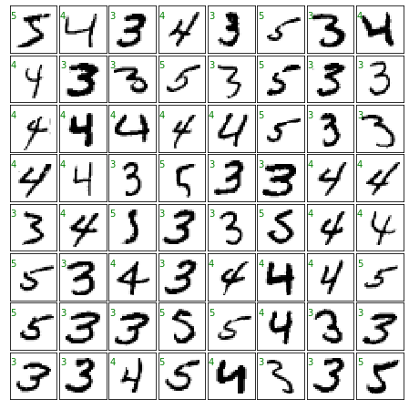

```python
fig = plt.figure(figsize=(6, 6))
fig.subplots_adjust(left=0, right=1,top=1, bottom=0, hspace=0.05, wspace=0.05)

for i in range(64):
    ax = fig.add_subplot(8, 8, i + 1, xticks=[], yticks=[])
    ax.imshow(x_train[i], cmap='Greys',interpolation='nearest')
    ax.text(0, 7, str(y_train[i]) ,color='g')
plt.show()
```

[figure not shown]

```python
sample3 = x_train3/255
sample4 = x_train4/255
sample5 = x_train5/255

all_mean3 = sample3.mean(axis=(1,2))
all_mean4 = sample4.mean(axis=(1,2))
all_mean5 = sample5.mean(axis=(1,2))

fig = plt.figure(figsize=(12,5), dpi=80)
plt.hist(all_mean3, bins=50, color='y', label='3')
plt.hist(all_mean4, bins=50, color='g', alpha=0.5, label='4')
plt.hist(all_mean4, bins=50, color='c', alpha=0.5, label='5')
plt.axvline(all_mean3.mean(), color='b', linestyle='dashed', linewidth=1, label='mean of 3')
plt.axvline(all_mean4.mean(), color='r', linestyle='dashed', linewidth=1, label='mean of 4')
plt.axvline(all_mean5.mean(), color='m', linestyle='dashed', linewidth=1, label='mean of 5')
plt.legend()
plt.title('Average')
plt.show()
```

### Visualization of Our Training Data

We use multidimensional scaling (MDS) to give a skretch of our training data.

```python
def plot_embedding(X, title=None):
    x_min, x_max = np.min(X, 0), np.max(X, 0)
    X = (X - x_min) / (x_max - x_min)

    plt.figure(figsize=(12,5), dpi=80)
    ax = plt.subplot(111)
    for i in range(X.shape[0]):
        plt.text(X[i, 0], X[i, 1], str(y_train[i]),
                 color=plt.cm.Set1(y_train[i] / 10.),
                 fontdict={'weight': 'bold', 'size': 9})
    plt.xticks([]), plt.yticks([])
    if title is not None:
        plt.title(title)
```

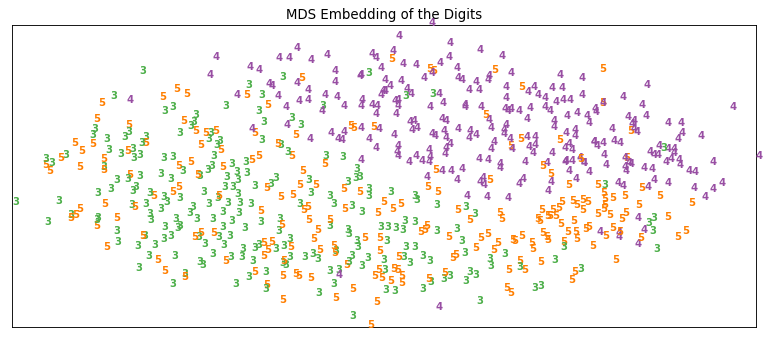

```python
from sklearn import manifold

clf = manifold.MDS(n_components=2, n_init=1, max_iter=100)
X_mds = clf.fit_transform(x_train.reshape(14466, 784)[:700,],y_train[:700,])

plot_embedding(X_mds,"MDS Embedding of the Digits")
plt.show()
```